# Project - Analysis of Medical Cost of people

### Author : Ashish Johnson

### Data Description:

The data at hand contains medical costs of people characterized by certain attributes.

### Domain:

Healthcare

### Context:

Leveraging customer information is paramount for most businesses. In the case of an insurance company, attributes of customers can be crucial in making business decisions. Hence, knowing to explore and generate value out of such data can be an invaluable skill to have.

### Attribute Information :

**age :** age of primary beneficiary  
**sex :** insurance contractor gender, female, male  
**bmi :** Body mass index, providing an understanding of body, weights that are relatively high or low relative to height, objective index of body weight (kg / m ^ 2) using the ratio of height to weight, ideally 18.5 to 24.9  
**children :** Number of children covered by health insurance / Number of dependents  
**smoker :** Smoking  
**region :** the beneficiary's residential area in the US, northeast, southeast, southwest, northwest.  
**charges :** Individual medical costs billed by health insurance.

### Objective:

We want to see if we can dive deep into this data to find some valuable insights.

### 1. Import the necessary libraries

```python
import numpy             as np
import pandas            as pd
import matplotlib.pyplot as plt
import seaborn           as sns

%matplotlib inline
sns.set(color_codes = True)
```

### 2. Read the data as a data frame

```python
df = pd.read_csv('insurance.csv')
```

### 3.1 Let's see the shape of the data-frame

```python
df.shape
```

```
(1338, 7)
```

There are **1338 rows** and **7 columns**  
Now lets look at the first 5 rows of the data-frame

```python
df.head()
```

|  | age | sex | bmi | children | smoker | region | charges |
| --- | --- | --- | --- | --- | --- | --- | --- |
| 0 | 19 | female | 27.900 | 0 | yes | southwest | 16884.92400 |
| 1 | 18 | male | 33.770 | 1 | no | southeast | 1725.55230 |
| 2 | 28 | male | 33.000 | 3 | no | southeast | 4449.46200 |
| 3 | 33 | male | 22.705 | 0 | no | northwest | 21984.47061 |
| 4 | 32 | male | 28.880 | 0 | no | northwest | 3866.85520 |

### 3.2 Lets look at the data type of each attribute

```python
df.info()
```

```
<class 'pandas.core.frame.DataFrame'>
RangeIndex: 1338 entries, 0 to 1337
Data columns (total 7 columns):
 #   Column    Non-Null Count  Dtype
---  ------    --------------  -----
 0   age       1338 non-null   int64
 1   sex       1338 non-null   object
 2   bmi       1338 non-null   float64
 3   children  1338 non-null   int64
 4   smoker    1338 non-null   object
 5   region    1338 non-null   object
 6   charges   1338 non-null   float64
dtypes: float64(2), int64(2), object(3)
memory usage: 73.3+ KB
```

Observations :

1. Attributes **age** and **children** are of type **Integer**
2. Attributes **bmi** and **charges** are of type **Float**
3. Attributes **sex**, **smoker** and **region** are of type **object** or **non-numeric** </font>

### 3.3 Lets check for any missing values in the data-frame

```python
df.isnull().sum()
```

```
age         0
sex         0
bmi         0
children    0
smoker      0
region      0
charges     0
dtype: int64
```

All the columns show the sum of nulls as zero implying **there is no missing values in any of the columns** in the data-frame

### 3.4 Let's look at the 5 point summary of numeric attributes

```python
df.describe()
```

|  | age | bmi | children | charges |
| --- | --- | --- | --- | --- |
| count | 1338.000000 | 1338.000000 | 1338.000000 | 1338.000000 |
| mean | 39.207025 | 30.663397 | 1.094918 | 13270.422265 |
| std | 14.049960 | 6.098187 | 1.205493 | 12110.011237 |
| min | 18.000000 | 15.960000 | 0.000000 | 1121.873900 |
| 25% | 27.000000 | 26.296250 | 0.000000 | 4740.287150 |
| 50% | 39.000000 | 30.400000 | 1.000000 | 9382.033000 |
| 75% | 51.000000 | 34.693750 | 2.000000 | 16639.912515 |
| max | 64.000000 | 53.130000 | 5.000000 | 63770.428010 |

Observations :

1. The mean and median for **age**, **bmi** and **children** attributes and nearly same but for **charges** the mean and median is significantly different indicating skewness
2. The standard deviation of **charges** is 12110 which is significantly huge indicating potential outliers </font>

### 3.5 Let's look at the distribution of continuous attributes

##### Distribution of 'bmi' attribute

```
Mean:  30.663396860986538
Median:  30.4
Mode:  32.3
```

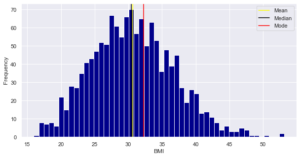

```python
mean  = df['bmi'].mean()
median= df['bmi'].median()
mode  = df['bmi'].mode()

print('Mean: ',mean,'\nMedian: ',median,'\nMode: ',mode[0])

plt.figure(figsize=(10,5))                        # set the figure size
plt.hist(df['bmi'],bins=50,color='darkblue')      #Plot the histogram

plt.axvline(mean,color='yellow',label='Mean')     # Draw lines on the plot for mean median and the two modes we have in GRE Score
plt.axvline(median,color='black',label='Median')
plt.axvline(mode[0],color='red',label='Mode')

plt.xlabel('BMI')                                 # label the x-axis
plt.ylabel('Frequency')                           # label the y-axis
plt.legend()                                      # Plot the legend
plt.show()
```

Observations :

1. The **BMI** attribuet follows normal distribution
2. The mean and median are almost same implying no data skewness which is seen from the distribution curve </font>

##### Distribution of 'age' attribute

[output not shown]

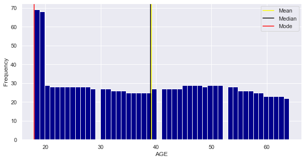

```python
mean  = df['age'].mean()
median= df['age'].median()
mode  = df['age'].mode()

print('Mean: ',mean,'\nMedian: ',median,'\nMode: ',mode[0])

plt.figure(figsize=(10,5))                        # set the figure size
plt.hist(df['age'],bins=50,color='darkblue')      #Plot the histogram

plt.axvline(mean,color='yellow',label='Mean')     # Draw lines on the plot for mean median and the two modes we have in GRE Score
plt.axvline(median,color='black',label='Median')
plt.axvline(mode[0],color='red',label='Mode')

plt.xlabel('AGE')                                 # label the x-axis
plt.ylabel('Frequency')                           # label the y-axis
plt.legend()                                      # Plot the legend
plt.show()
```

Observations :

##### Distribution of 'charges' attribute

```
Mean:  13270.422265141257
Median:  9382.033
Mode:  1639.5631
```

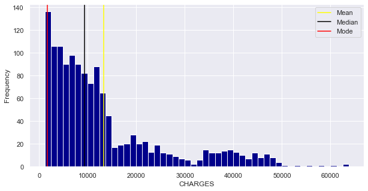

```python
mean  = df['charges'].mean()
median= df['charges'].median()
mode  = df['charges'].mode()

print('Mean: ',mean,'\nMedian: ',median,'\nMode: ',mode[0])

plt.figure(figsize=(10,5))                        # set the figure size
plt.hist(df['charges'],bins=50,color='darkblue')  #Plot the histogram

plt.axvline(mean,color='yellow',label='Mean')     # Draw lines on the plot for mean median and the two modes we have in GRE Score
plt.axvline(median,color='black',label='Median')
plt.axvline(mode[0],color='red',label='Mode')

plt.xlabel('CHARGES')                             # label the x-axis
plt.ylabel('Frequency')                           # label the y-axis
plt.legend()                                      # Plot the legend
plt.show()
```

1. The Mean is greater than Median for **charges** attribute implying outliers
2. The data is right skewed due to potential outliers </font>

### 3.6 Let's measure skewness of ‘bmi’, ‘age’ and ‘charges’ columns

```python
print ('Measure of skewness of "BMI" attribute     : ', df['bmi'].skew())
print ('Measure of skewness of "AGE" attribute     : ', df['age'].skew())
print ('Measure of skewness of "CHARGES" attribute : ', df['charges'].skew())
```

```
Measure of skewness of "BMI" attribute     :  0.2840471105987448
Measure of skewness of "AGE" attribute     :  0.05567251565299186
Measure of skewness of "CHARGES" attribute :  1.5158796580240388
```

Observations :

1. All the three attributes are positively skewed (mean > median)
2. The skewness of **age** attribute is almost zero implying almost no skewness
3. The **charges** attribute has a value of skewness > 1.5 implying outliers and most frequent values are low and tail is towards high values </font>

### 3.7 Let's check the presence of outliers in ‘bmi’, ‘age’ and ‘charges

**Box Plot of 'bmi' attribute**

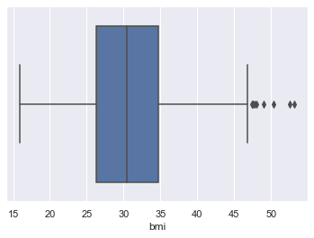

```python
sns.boxplot(x=df['bmi']);
```

**Box Plot of 'age' attribute**

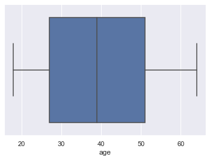

```python
sns.boxplot(x=df['age']) ;
```

**Box Plot of 'charges' attribute**

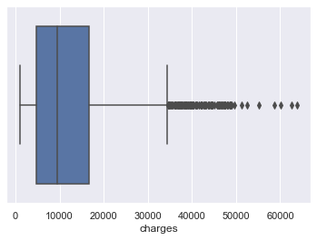

```python
sns.boxplot(x=df['charges']);
```

Observations :

1. The **bmi** attribute has outliers on the high values side, which is also supported by the skewness value of 0.28
2. The **age** attribute has no outliers and is supported by skewness value of 0.05
3. The **charges** attrinute has a lot of outliers on the high value side which is supported by the fact that mean is much larger than median and skewness value of 1.51 </font>

### 3.8 Let's check the distribution of categorical columns

##### Distribution of 'sex' attribute

```
male      676
female    662
Name: sex, dtype: int64
```

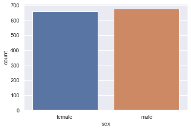

```python
print (df['sex'].value_counts())

sns.countplot(df['sex']) ;
```

##### Distribution of 'smoker' attribute

```
no     1064
yes     274
Name: smoker, dtype: int64
```

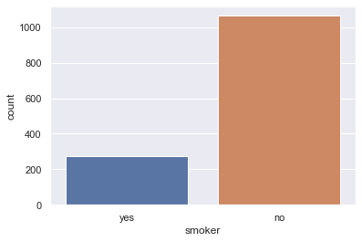

```python
print (df['smoker'].value_counts())

sns.countplot(df['smoker']) ;
```

##### Distribution of 'region' attribute

```
southeast    364
southwest    325
northwest    325
northeast    324
Name: region, dtype: int64
```

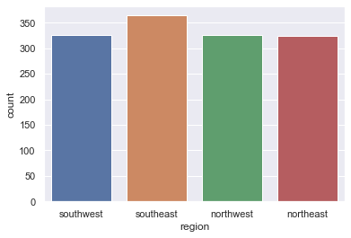

```python
print (df['region'].value_counts())

sns.countplot(df['region']) ;
```

##### Distribution of 'children' attribute

```
0    574
1    324
2    240
3    157
4     25
5     18
Name: children, dtype: int64
```

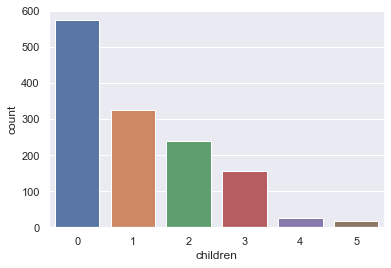

```python
print (df['children'].value_counts())

sns.countplot(df['children']) ;
```

Observations :

1. The distribution of males and females in the data-set are almost equal. Only 14 more males than females
2. The data-set contains approximately 4 times non-smokers compared to smokers
3. The data-set has almost even distribution across 4 regions. The 'southweast' region is marginally high compared to other three regions
4. Most people have 2 or less children. Very few people have 3 or more children. Most of the people in the data-set do not have any children. </font>

### 3.9 Pair Plot of all the attributes of the data-frame

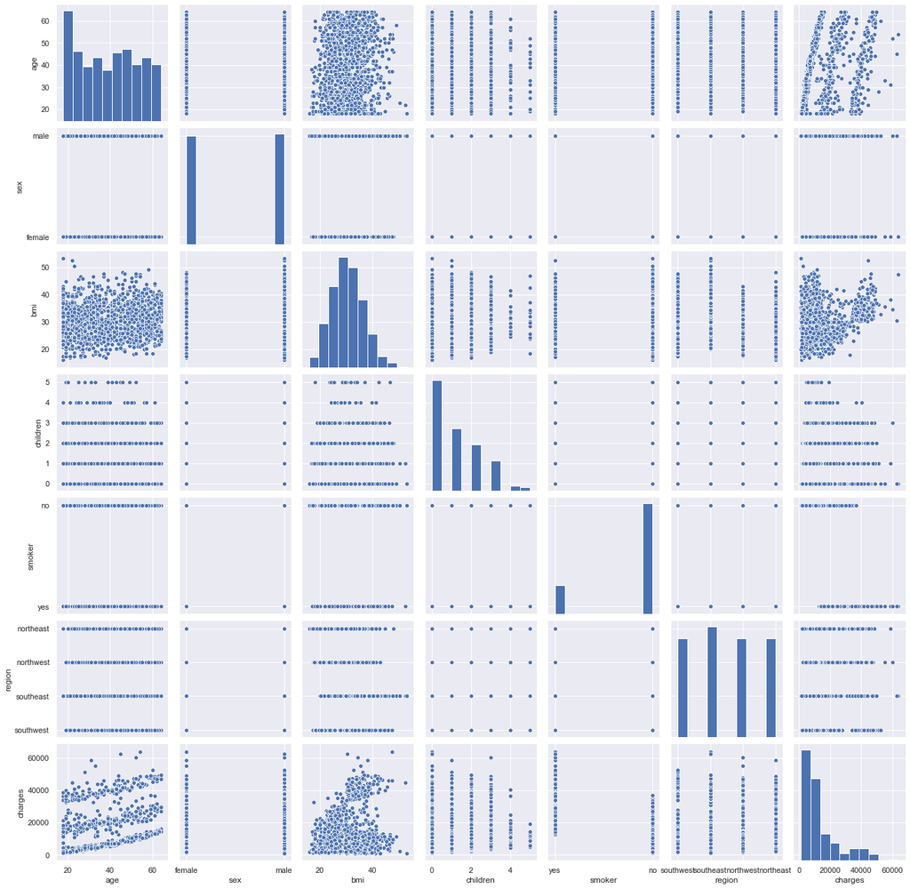

```python
sns.pairplot(data = df, vars = ['age', 'sex', 'bmi', 'children', 'smoker', 'region', 'charges']) ;
```

### 4.1 Let's check if the charges of people who smoke differ significantly from the people who don't

We will first establish the Null and Alternate Hypothesis as follows :  
**Ho = charges of smokers and non-smokers do not differ**  
**Ha = charges of smokers and non-smokers vary significantly**  
**Significance level = 5%**

```python
print (df['smoker'].value_counts())
```

```
no     1064
yes     274
Name: smoker, dtype: int64
```

```python
nonsmoker_grp = df[df['smoker'] == 'no']
smoker_grp    = df[df['smoker'] == 'yes']
```

```python
from scipy.stats import ttest_ind

# two-sample t-test
t_statistic, p_value = ttest_ind(nonsmoker_grp['charges'], smoker_grp['charges'])
print ('t_statistic value : ', t_statistic)
print ('p_value           : ', p_value, '\n\n')

# p_value < 0.05 => alternative hypothesis:
# they don't have the same mean at the 5% significance level
if p_value < 0.05 :
    print (f'We reject the Null Hypothesis since {p_value} < 0.05 ')
else :
    print (f'We fail to reject the null Hypothesis since {p_value} >= 0.05')
```

```
t_statistic value :  -46.664921172723716
p_value           :  8.271435842177219e-283


We reject the Null Hypothesis since 8.271435842177219e-283 < 0.05
```

Observations :

1. The charges paid by smokers is **46 standard deviations more** than that paid by non smokers
2. Since p value is much less than 0.05 we **reject the null hypothesis at 95% confidence level**
3. This implies we **accept the alternate hypothesis** that there is a **significant difference in the charges paid by smokers compared to non-smokers**
4. The same is visualized in the scatter plot below </font>

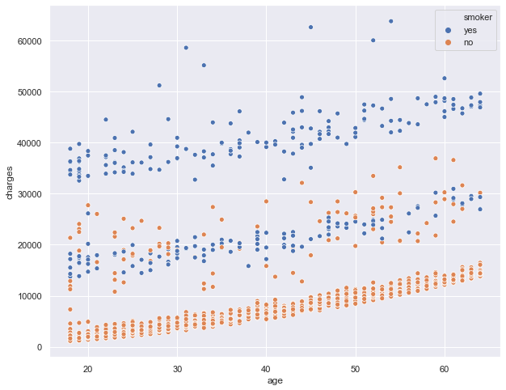

```python
plt.figure(figsize=(10,8))
sns.scatterplot(x=df['age'], y=df['charges'], hue=df['smoker']) ;
```

### 4.2 Let's check if the BMI of males differ significantly from that of females

Again, we establish the Null and Alternate Hypothesis as follows :  
**Ho = Gender has no impact on BMI**  
**Ha = Gender has an impact on BMI**  
**Significance level = 5%**

```python
print (df['sex'].value_counts())
```

```
male      676
female    662
Name: sex, dtype: int64
```

```python
males_grp   = df[df['sex'] == 'male']
females_grp = df[df['sex'] == 'female']
```

```python
from scipy.stats import ttest_ind

# two-sample t-test
t_statistic, p_value = ttest_ind(males_grp['bmi'], females_grp['bmi'])
print ('t_statistic value : ', t_statistic)
print ('p_value           : ', p_value, '\n\n')

# p_value < 0.05 => alternative hypothesis:
# they don't have the same mean at the 5% significance level
if p_value < 0.05 :
    print (f'We reject the Null Hypothesis since {p_value} < 0.05 ')
else :
    print (f'We fail to reject the null Hypothesis since {p_value} >= 0.05')
```

```
t_statistic value :  1.696752635752224
p_value           :  0.08997637178984932


We fail to reject the null Hypothesis since 0.08997637178984932 >= 0.05
```

Observations :

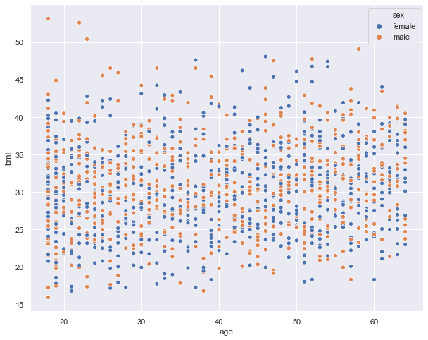

```python
plt.figure(figsize=(10,8))
sns.scatterplot(x=df['age'], y=df['bmi'], hue=df['sex']) ;
```

### 4.3 Let's check if the proportion of smokers is significantly different in different genders

Again, we establish the Null and Alternate Hypothesis as follows :

**Ho = Proportion of smokers in males and females is same**  
**Ha = Proportion of smokers in males and females is different**  
</font>

```python
female_smokers = df[df['sex'] == 'female'].smoker.value_counts()[1]  # number of female smokers
male_smokers   = df[df['sex'] == 'male'].smoker.value_counts()[1]    # number of male smokers
n_females = df.sex.value_counts()[1]                                 # number of females in the data
n_males   = df.sex.value_counts()[0]                                 #number of males in the data

print ('Total number of females           : ', n_females)
print ('Total number of females who smoke : ', female_smokers)
print ('\n')
print ('Total number of males             : ', n_males)
print ('Total number of males who smoke   : ', male_smokers)
```

```
Total number of females           :  662
Total number of females who smoke :  115


Total number of males             :  676
Total number of males who smoke   :  159
```

```python
print(f' Proportion of smokers in females, males = {round(115/662,2)}%, {round(159/676,2)}% respectively')
```

```
 Proportion of smokers in females, males = 0.17%, 0.24% respectively
```

The proportions are different but are they statistically significant?

```python
from statsmodels.stats.proportion import proportions_ztest

zstat, pval = proportions_ztest([female_smokers, male_smokers] , [n_females, n_males])

print ('z_statistic value : ', zstat)
print ('p_value           : ', pval, '\n\n')

if pval < 0.05:
    print(f'With a p-value of {round(pval,4)} the difference is significant. aka |We reject the null|')
else:
    print(f'With a p-value of {round(pval,4)} the difference is not significant. aka |We fail to reject the null|')
```

```
z_statistic value :  -2.7867402154855503
p_value           :  0.005324114164320532


With a p-value of 0.0053 the difference is significant. aka |We reject the null|
```

Observations :

1. The proportion of smokers in males is **2.7 standard deviations more** than that of females
2. Since p value is less than 0.05 we **reject the null hypothesis at 95% confidence level**
3. This implies **Proportion of smokers in males is significantly different from that of the females** </font>

### 4.4 Let's check if the distribution of bmi across women with no children, one child and two children, the same

We establish the Null and Alternate Hypothesis as follows :  
**Ho = No of children has no effect on BMI of females**  
**Ha = No of children has an effect on BMI of females**

```python
from scipy.stats import f_oneway

female_grp = df[df['sex'] == 'female']

no_child_bmi  = female_grp[female_grp['children'] == 0]['bmi']
one_child_bmi = female_grp[female_grp['children'] == 1]['bmi']
two_child_bmi = female_grp[female_grp['children'] == 2]['bmi']

f_stat, p_value = f_oneway(no_child_bmi, one_child_bmi, two_child_bmi)
print ('p_value           : ', p_value, '\n\n')

if p_value < 0.05:
    print(f'With a p-value of {round(p_value,4)} the BMI variation is significant. aka |We reject the null|')
else:
    print(f'With a p-value of {round(p_value,4)} the BMI variation is not significant. aka |We fail to reject the null|')
```

```
p_value           :  0.7158579926754841


With a p-value of 0.7159 the BMI variation is not significant. aka |We fail to reject the null|
```

Observations :

1. Since p value is much greater than 0.05 we **fail to reject the null hypothesis at 95% confidence level**
2. This implies **Number of children has no effect on BMI of females** </font>